# F Test p-values

## Heading towards a p-value

p-value: If \(H_0\) is correct, what proportion of samples would give you F statistics at least as extreme as the F statistic of 4.78 we got from our actual data?

Let's simulate a fake data set, assuming \(H_0\) is true. We have 9 observations drawn at random from a Normal(3.033, 0.579) distribution.

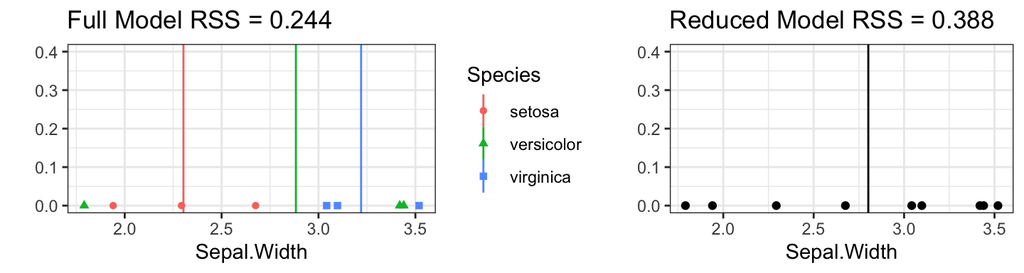

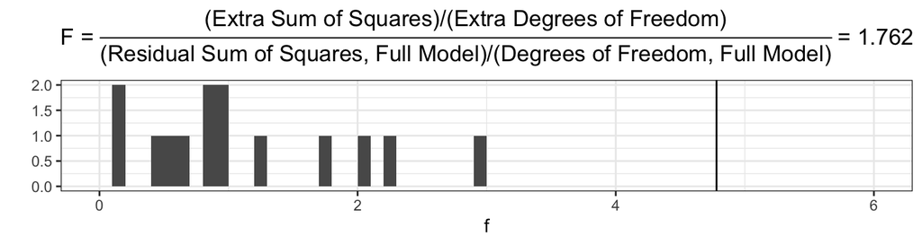

## Heading towards a p-value

p-value: If \(H_0\) is correct, what proportion of samples would give you F statistics at least as extreme as the F statistic of 4.78 we got from our actual data?

Let's simulate a fake data set, assuming \(H_0\) is true. We have 9 observations drawn at random from a Normal(3.033, 0.579) distribution.

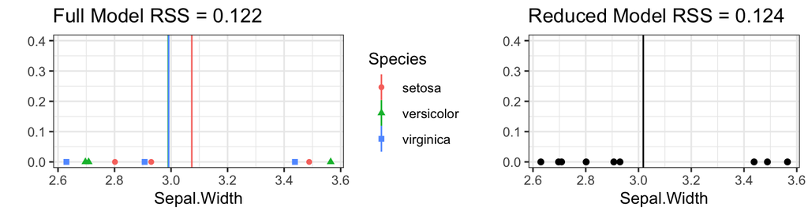

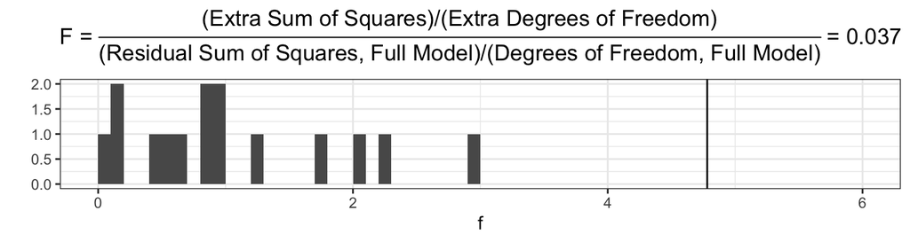

## Heading towards a p-value

p-value: If \(H_0\) is correct, what proportion of samples would give you F statistics at least as extreme as the F statistic of 4.78 we got from our actual data?

Let's simulate a fake data set, assuming \(H_0\) is true. We have 9 observations drawn at random from a Normal(3.033, 0.579) distribution.

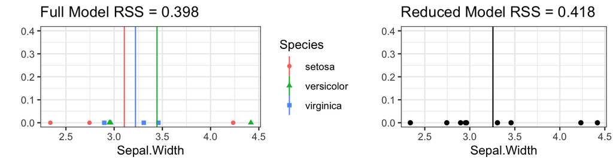

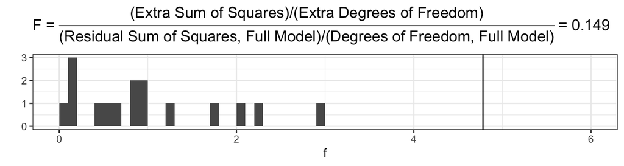

## Heading towards a p-value

p-value: If \(H_0\) is correct, what proportion of samples would give you F statistics at least as extreme as the F statistic of 4.78 we got from our actual data?

Let's simulate a fake data set, assuming \(H_0\) is true. We have 9 observations drawn at random from a Normal(3.033, 0.579) distribution.

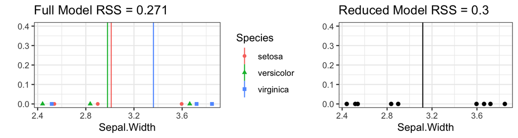

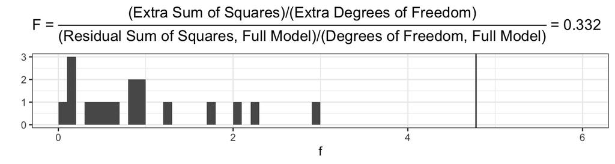

## Heading towards a p-value

p-value: If \(H_0\) is correct, what proportion of samples would give you F statistics at least as extreme as the F statistic of 4.78 we got from our actual data?

F statistics from 10,000 more samples, all generated assuming \(H_0\) is true. The orange curve shows the theoretically derived F distribution.

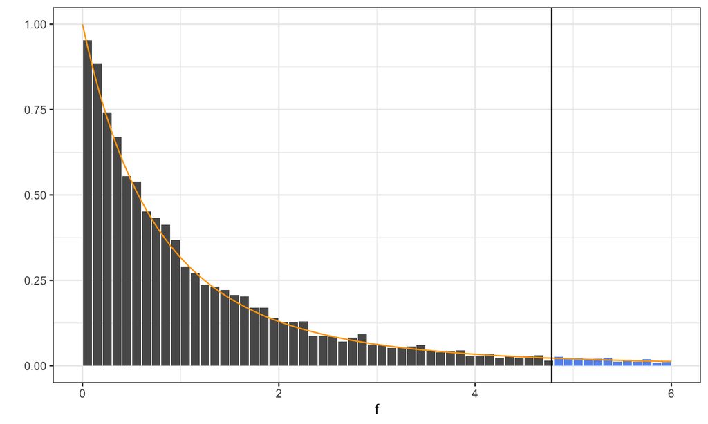

## A p-value

- The p-value is 0.05732
- If the null hypothesis that all three species had the same population mean were true, about 5.7% of samples would give you F statistics at least as extreme as the F statistic of 4.78 we got from our actual data. (Those samples contribute to the blue part of the histogram.)
- This offers some evidence against \(H_0\), but not very strong.

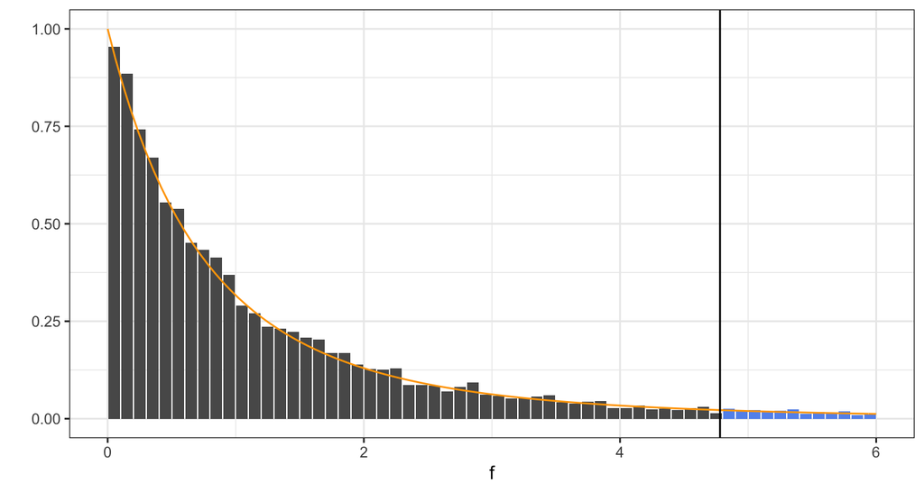